# robust_statistics

[figure not shown]

Acharya N.G. Ranga Agricultural University

Agricultural College, Bapatla

Department of Statistics and Computer Applications

STAT 601 Advanced Data Analytics (1+2)

Robust Statistics

Presenter Krupesh S (BAD/2025-25) I Ph.D.(Ag.) Agricultural Statistics

Course In-charge Dr. B. Jyostna Teaching Associate (Statistics)

# INTRODUCTION

## Departure from Normality

A contaminated normal distribution given by Tukey and Huber can be represented as,
$$F=(1-\epsilon) G+\epsilon H$$
where, $G = N(\mu, \sigma^2)$ and H is any distribution.

# M-ESTIMATORS OF LOCATION

## Location Model

$x_i = \mu + u_i$ where $u_i$ $(i=1, \dots, n)$ are random variables.
$$\begin{align*}
F(x) &= P(x_i \leq x) && \text{Definition of CDF} & \\
&= P(\mu + u_i \leq x) && \text{Substitute model } x_i = \mu + u_i & \\
&= P(u_i \leq x - \mu) && \text{Rearrange to isolate } u_i & \\
&= F_0(x - \mu) && \text{Apply error distribution } F_0 & \\
\therefore F(x) &= F_0(x - \mu) && &
\end{align*}$$

Here, $x_i$ are i.i.d. random variables.

Also, $F_0(x) = 1 - F_0(-x)$.

If $F_0 = N(0, \sigma^2)$, then,

- $\text{mean}(x) \sim N(0,\, \sigma^2/n)$
- $\text{med}(x) \approx N(0,\, 1.57 \times \sigma^2/n)$

Thus, for a pure normal distribution, mean is 57% more efficient than the median.

## Formulation

Consider $f_0 = F_0'$, the density of the location model. Then, the joint density of the model is given as,

$$L(x_i;\, \mu) = \prod_{i=1}^{n} f_0(x_i - \mu)$$

The MLE of $\mu$ is $\hat{\mu}$, such that,

$$\hat{\mu} = \hat{\mu}(x_i) = \arg\max_{\mu}\, L(x_i;\, \mu)$$

If $F_0$ is exactly known, the MLE will be the optimal. Since $F_0$ is only approximately known, the goal is to find “nearly optimal” estimators for,

- when $F_0$ is normal
- when $F_0$ is approximately normal

## Estimation

If $f_0$ is everywhere positive, since the logarithm is an increasing function, $\hat{\mu}$ can be written as,

$$\hat{\mu} = \arg\min_{\mu} \sum_{i=1}^{n} \rho(x_i - \mu)$$

where,

$$\rho = -\log f_0$$

For some unknown $f_0$ and a function $\rho$, this problem can be solved using the implicit equation,

$$\sum_{i=1}^{n} \psi(x_i - \hat{\mu}) = 0$$

where,

$$\psi = \rho'$$

## The Weighted Mean Interpretation

The equation,

$$\sum_{i=1}^{n} \psi(x_i - \hat{\mu}) = 0$$

can be written as,

$$\sum_{i=1}^{n} W(x_i - \hat{\mu})(x_i - \hat{\mu}) = 0$$

$$\implies \sum_{i=1}^{n} W_i x_i = \sum_{i=1}^{n} W_i \hat{\mu}$$

$$\implies \hat{\mu} = \frac{\sum_{i=1}^{n} W_i x_i}{\sum_{i=1}^{n} W_i}$$

**Weighted Mean of Sample**

$\hat{\mu} = \dfrac{\sum_{i=1}^{n} W_i x_i}{\sum_{i=1}^{n} W_i}$ is simply a **weighted mean** of the sample.

where,

$$W(x) = \begin{cases} \psi(x)/x & \text{if } x \neq 0 \\ \psi'(0) & \text{if } x = 0 \end{cases}$$

and,

$$W_i = W(x_i - \hat{\mu})$$

## Formal Definition

A $\rho$-function will denote a function $\rho$ such that:

- $\rho(x)$ is a nondecreasing function of $|x|$
- $\rho(0) = 0$
- $\rho(x)$ is increasing for $x > 0$ such that $\rho(x) < \rho(\infty)$
- if $\rho$ is bounded, it is also assumed that $\rho(\infty) = 1$.

A $\psi$-function will denote a function $\psi$ that is the derivative of a $\rho$-function, which implies in particular that

- $\psi$ is odd and $\psi(x) \geq 0$ for $x \geq 0$.

## Yet another interpretation

Another intuitive way to interpret an M-estimator is,
$$\hat{\mu} = \hat{\mu} + \frac{1}{n} \sum_{i=1}^{n} \psi(x_i - \hat{\mu}) = \frac{1}{n} \sum_{i=1}^{n} \zeta(x_i, \hat{\mu})$$
where
$$\zeta(x, \mu) = \mu + \psi(x - \mu)$$
In other words, $\hat{\mu}$ may be viewed as an average of modified observations $\zeta(x_i, \hat{\mu})$, also called pseudo observations:observations in the bulk of the data remain unchanged, while those too large or too small are truncated.

## Common M-Estimator Functions

[output not shown]

* Note for Hampel: $C = \frac{a}{2}(b - a + r)$.

## Behaviour of Common M-Estimators

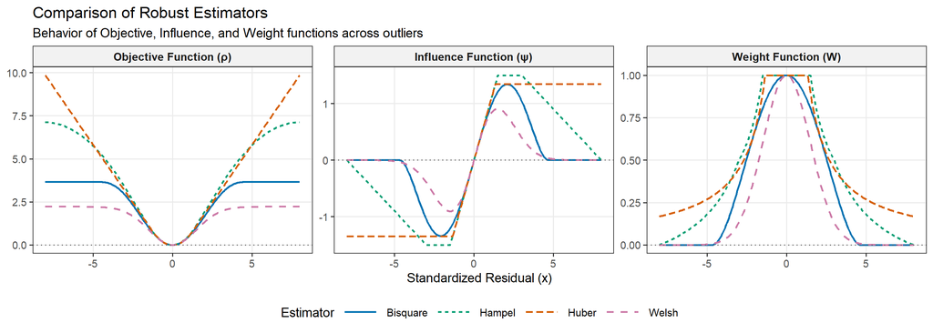

# TRIMMED AND WINSORIZED MEAN

## Definition

The $\alpha$-**trimmed mean** is defined as:

$$\bar{x}_\alpha = \frac{1}{n - 2m} \sum_{i=m+1}^{n-m} x_{(i)}$$

The $\alpha$-**Winsorized mean** is defined as:

$$\tilde{x}_\alpha = \frac{1}{n} \left( m x_{(m+1)} + m x_{(n-m)} + \sum_{i=m+1}^{n-m} x_{(i)} \right)$$

where,

- $n$: The total number of observations.
- $x_{(i)}$: The order statistics of the sample, such that $x_{(1)} \leq x_{(2)} \leq \dots \leq x_{(n)}$.
- $\alpha$: The trimming proportion, where $\alpha \in [0, 1/2)$.
- $m$: The integer number of trimmed values, defined as $m = [n\alpha]$, where $[\cdot]$ stands for the integer part.

**Limiting Case**

- **Case $\alpha \to 0$ ($m = 0$):** No data is discarded. Both estimators reduce to the standard **Sample Mean**.
- **Case $\alpha \to 0.5$ ($m \approx n/2$):** The maximum amount of data is trimmed/replaced. Both estimators converge to the **Sample Median**.

# L-ESTIMATORS

## Definition

A more general class of estimators, called *L-estimators*, is defined as linear combinations of order statistics:

$$\hat{\mu} = \sum_{i=1}^{n} a_i x_{(i)},$$

where the $a_i$s are given constants. For $\alpha$-trimmed means,

$$a_i = \frac{1}{n - 2m} \text{I}(m + 1 \leq i \leq n - m),$$

and for $\alpha$-Winsorized means

$$a_i = \frac{1}{n} \Big( (m + 1)\text{I}(i = m + 1) + (m + 1)\text{I}(i = n - m) + \text{I}(m + 1 < i < n - m) \Big) .$$

## Equivariance

If the coefficients of an L-estimator satisfy the conditions

$$a_i \geq 0, \quad \sum_{i=1}^{n} a_i = 1, \quad a_i = a_{n-i+1},$$

then the estimator is shift and scale equivariant, and also fulfills the natural conditions

- If $x_i \geq 0$ for all $i$, then $\hat{\mu} \geq 0$
- If $x_i = c$ for all $i$, then $\hat{\mu} = c$
- $\hat{\mu}(-x) = -\hat{\mu}(x)$.

# M-ESTIMATORS OF SCALE

## Scale Model

$x_i = \sigma u_i$ where $u_i \ (i = 1,\dots,n)$ are i.i.d. random variables with density $f_0$ and $\sigma > 0$.

$$\begin{aligned}
F(x) &= P(x_i \leq x) & &\text{Definition of CDF} \\
&= P(\sigma u_i \leq x) & &\text{Substitute model } x_i = \sigma u_i \\
&= P\left(u_i \leq \frac{x}{\sigma}\right) & &\text{Rearrange to isolate } u_i \\
&= F_0\left(\frac{x}{\sigma}\right) & &\text{Apply error distribution } F_0
\end{aligned}$$

$\therefore F(x) = F_0\left(\frac{x}{\sigma}\right)$

Differentiating the CDF with respect to $x$ yields the density (PDF):

$$\begin{aligned}
f(x) &= \frac{d}{dx} F(x) & &\text{Definition of PDF} \\
&= \frac{d}{dx} F_0\left(\frac{x}{\sigma}\right) & &\text{Substitute derived CDF} \\
&= f_0\left(\frac{x}{\sigma}\right) \cdot \frac{1}{\sigma} & &\text{Apply Chain Rule}
\end{aligned}$$

$\therefore f(x) = \frac{1}{\sigma} f_0\left(\frac{x}{\sigma}\right)$

## Estimation

The MLE of $\sigma$ is found from

$$\hat{\sigma} = \arg\max_{\sigma} \frac{1}{\sigma^n} \prod_{i=1}^{n} f_0 \left( \frac{x_i}{\sigma} \right)$$

Taking logs and differentiating with respect to $\sigma$, yields the condition:

$$\frac{1}{n} \sum_{i=1}^{n} \rho \left( \frac{x_i}{\sigma} \right) = 1$$

where $\rho(t) = t\psi(t)$ and $\psi = -f'_0/f_0$. Generalizing this result, any estimator $\hat{\sigma}$ satisfying the equation

$$\frac{1}{n} \sum_{i=1}^{n} \rho \left( \frac{x_i}{\hat{\sigma}} \right) = \delta$$

where $\delta$ is a positive constant, is called an M-estimator of scale.

## Dispersion Estimators

- **Median Absolute Deviation (MAD)** It measures the median distance of observations from the sample median.

  $$\text{MAD} = \text{median}(|x_i - \text{median}(x)|)$$
- **Mean Absolute Deviation (MD)** The arithmetic mean of the absolute differences between observations and the sample mean.

  $$\text{MD} = \frac{1}{n} \sum_{i=1}^{n} |x_i - \bar{x}|$$
- **Interquartile Range (IQR)** The difference between the 75th and 25th percentiles.

  $$\text{IQR} = x_{(n-m+1)} - x_{(m)}$$

  where $m \approx n/4$.

## Multiples of Scale

If $x \sim N(\mu, \sigma^2)$, then $\text{SD}(x) = \sigma$. The other dispersion estimators are constant multiples of $\sigma$:

$$\text{MD}(x) = c_1 \sigma \qquad \text{MAD}(x) = c_2 \sigma \qquad \text{IQR}(x) = 2c_2 \sigma$$

Where the approximate constant values are:

$$c_1 = 2\varphi(0) = \sqrt{\frac{2}{\pi}} \approx 0.7979 \qquad c_2 = \Phi^{-1}(0.75) \approx 0.675$$

To create a dispersion estimator that “measures the same thing” as the standard deviation for the normal distribution, we define the Normalized MAD (MADN):

$$\text{MADN}(x) = \frac{\text{MAD}(x)}{0.675}$$

Likewise, we can normalize the MD and the IQR by dividing them by $c_1$ and by $2c_2$ respectively.

## M-Dispersion Estimators

An estimator that combines the robustness of MADN and the efficiency of SD and MD is the following:

- first compute a location M-estimator $\hat{\mu}$.
- Then apply a scale M-estimator $\hat{\sigma}$ to the centered data $x_i - \hat{\mu}$.
- Here $\hat{\sigma}$ should be normalized as described. This $\hat{\sigma}$ can be called the *M-dispersion estimator*.

## The $Q_n$ alternative

Unlike the SD, MD, and MAD, an estimator called the $Q_n$ estimator (Croux and Rousseeuw, 1992) does not require centering the data.

- It is based strictly on the differences between data values: $d_{ij} = |x_i - x_j|$ for $i < j$.
- Let $m = \binom{n}{2}$ be the number of differences, ordered as $d_{(1)} \leq \dots \leq d_{(m)}$.
- Define
  $$h = \lfloor \frac{n}{2} \rfloor + 1, \qquad k = \binom{h}{2}.$$
  The estimator is defined as the $k$-th order statistic: $Q_n = d_{(k)}$.
- Since $k \approx m/4$, $Q_n$ is approximately the first quartile of the $d_{ij}$ values.

# NUMERICAL ESTIMATION

## Location M-Estimators

- **Initialization:** Start with a robust dispersion estimator ($\hat{\sigma}$) and an initial location estimator ($\hat{\mu}_0$):
  $$\hat{\sigma} = \text{MADN}(\mathbf{x}), \quad \hat{\mu}_0 = \text{Med}(\mathbf{x})$$
- **Iterative Procedure** ($k = 0, 1, 2, \dots$):
  1. Compute the weights:
     $$w_{k,i} = W \left( \frac{x_i - \hat{\mu}_k}{\hat{\sigma}} \right) \quad \text{for } i = 1, \dots, n$$
  2. Update the location estimate:
     $$\hat{\mu}_{k+1} = \frac{\sum_{i=1}^{n} w_{k,i} x_i}{\sum_{i=1}^{n} w_{k,i}}$$
- **Stopping Rule:** Halt when the change falls below a tolerance parameter $\varepsilon$:
  $$|\hat{\mu}_{k+1} - \hat{\mu}_k| < \varepsilon \hat{\sigma}$$
- **Convergence Properties:**
  - If $\psi$ is *increasing*: The solution is unique.
  - If $\psi$ is *redescending*: Choosing a robust $\hat{\mu}_0$ ensures convergence to a valid solution.

## Scale M-Estimators

- **Initialization:** Start with an initial robust dispersion estimator ($\hat{\sigma}_0$):
  $$\hat{\sigma}_0 = \text{MADN}(\mathbf{x})$$
- **Iterative Procedure** ($k = 0, 1, 2, \dots$):
  1. Compute the weights:
     $$w_{k,i} = W \left( \frac{x_i}{\hat{\sigma}_k} \right) \quad \text{for } i = 1, \dots, n$$
  2. Update the scale estimate:
     $$\hat{\sigma}_{k+1} = \sqrt{ \frac{1}{n\delta} \sum_{i=1}^{n} w_{k,i} x_i^2 }$$
- **Stopping Rule:** Halt when the relative change falls below a tolerance parameter $\varepsilon$:
  $$\left| \frac{\hat{\sigma}_{k+1}}{\hat{\sigma}_k} - 1 \right| < \varepsilon$$
- **Convergence Properties:**
  - The sequence $\hat{\sigma}_k$ converges to a valid solution if $W(x)$ is:
    - bounded
    - even
    - continuous
    - nonincreasing for $x > 0$

## Simultaneous M-estimators

- **Initialization:** Compute robust starting values for both location and dispersion: $\hat{\mu}_0, \hat{\sigma}_0$
- **Iterative Procedure** ($k = 0, 1, 2, \dots$):
  1. Compute standardized residuals:
     $$r_{k,i} = \frac{x_i - \hat{\mu}_k}{\hat{\sigma}_k} \quad \text{for } i = 1, \dots, n$$
  2. Compute dual weights ($W_1$ for location, $W_2$ for scale):
     $$w_{1k,i} = W_1(r_{k,i}), \quad w_{2k,i} = W_2(r_{k,i})$$
  3. Update estimates simultaneously:
     $$\hat{\mu}_{k+1} = \frac{\sum_{i=1}^{n} w_{1k,i} x_i}{\sum_{i=1}^{n} w_{1k,i}}$$
     $$\hat{\sigma}_{k+1}^2 = \frac{\hat{\sigma}_k^2}{n\delta} \sum_{i=1}^{n} w_{2k,i} r_{k,i}^2$$
- **Stopping Rule:** Halt when both estimates stabilize below a tolerance parameter $\varepsilon$:
  $$|\hat{\mu}_{k+1} - \hat{\mu}_k| < \varepsilon \hat{\sigma}_k \quad \text{and} \quad \left| \frac{\hat{\sigma}_{k+1}}{\hat{\sigma}_k} - 1 \right| < \varepsilon$$

# MEASURES TO QUANTIFY ROBUSTNESS

- **Breakdown Point ($\varepsilon_n^*$):** The smallest fraction of data contamination that can cause the estimator $T$ to take on arbitrarily large values.

  $$\varepsilon_n^*(T, \mathbf{x}) = \min \left\{ \frac{m}{n} : \sup_{\mathbf{x}'} \|T(\mathbf{x}')\| = \infty \right\}$$

  *(where $\mathbf{x}'$ is obtained by replacing $m$ original points with arbitrary values)*
- **Influence Function ($IF$):** Measures the asymptotic bias caused by an infinitesimal point mass $\delta_x$ at $x$ on the functional $T$ at distribution $F$.

  $$IF(x; T, F) = \lim_{\varepsilon \to 0} \frac{T((1 - \varepsilon)F + \varepsilon \delta_x) - T(F)}{\varepsilon}$$

  *(A robust estimator requires a bounded Influence Function)*
- **Sensitivity Curve ($SC_n$):** The finite-sample, empirical counterpart to the Influence Function. It measures the scaled effect of adding an observation $x$ to a sample of size $n$.

  $$SC_n(x; T) = (n + 1) [T(x_1, \dots, x_n, x) - T(x_1, \dots, x_n)]$$

  *(As $n \to \infty$, $SC_n \to IF$)*

## Breakdown Points for Estimators

| Category | Estimator | Asymptotic Breakdown Point |
| --- | --- | --- |
| **Classical (Location)** | Sample Mean | 0 |
| **Classical (Scale)** | Standard Deviation (SD) | 0 |
| **Classical (Scale)** | Mean Absolute Deviation (MD) | 0 |
| **Robust (Location)** | Sample Median | 0.5 |
| **Robust (Location)** | α-Trimmed Mean | α |
| **Robust (Scale)** | MAD / MADN | 0.5 |
| **Robust (Scale)** | Qₙ Estimator | 0.5 |

# ILLUSTRATIONS IN R

## Dataset

We use the `telef` dataset from `robustbase` — the classic Belgium telephone data (1950–1973) recording the number of telephone calls (in tens of millions) over 24 years (Rousseeuw & Leroy, 1987). The mid-years **1964–1969** contain a known recording error (calls logged in minutes instead of numbers), producing **6 high-leverage outliers** that severely distort classical estimates.

```
n = 24
```

```
   Year Calls
1    50  0.44
2    51  0.47
3    52  0.47
4    53  0.59
5    54  0.66
6    55  0.73
7    56  0.81
8    57  0.88
9    58  1.06
10   59  1.20
```

```
      Year           Calls
 Min.   :50.00   Min.   : 0.440
 1st Qu.:55.75   1st Qu.: 0.790
 Median :61.50   Median : 1.550
 Mean   :61.50   Mean   : 4.999
 3rd Qu.:67.25   3rd Qu.: 6.200
 Max.   :73.00   Max.   :21.200
```

## Belgium Telephone Data

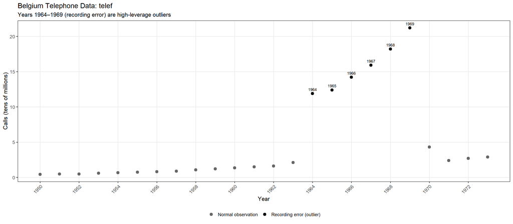

## Location Estimators

```r
library(robustbase)

data("telef")
x <- telef$Calls   # telephone calls — contains high-leverage outliers

# ----- Huber M-estimator of Location -----
# huberM(x, k, tol, mu, s, se)
#   x  : numeric vector
#   k  : tuning constant — boundary between quadratic and linear loss
#        default k = 1.5; use k = 1.345 for 95% efficiency at the Normal
#   mu : initial location estimate, default = median(x)
#   s  : initial scale estimate,    default = mad(x)
#   se : logical; compute standard error? default FALSE
huberM(x, k = 1.5)
```

```
$mu
[1] 2.21057

$s
[1] 1.512252

$it
[1] 11

$SE
[1] NA
```

```r
# ----- Trimmed Mean -----
# mean(x, trim)
#   trim : fraction (0 to 0.5) of observations dropped
#          from each tail before computing the mean
mean(x, trim = 0.10)     # removes bottom 10% and top 10%
```

```
[1] 3.9835
```

```r
# ----- Winsorized Mean (base R) -----
# Replaces the bottom and top `trim` fraction of values
# with the nearest kept boundary value, then takes the mean
winsor_mean <- function(x, trim = 0.10) {
  x_s <- sort(x)
  m   <- floor(trim * length(x_s))
  x_s[seq_len(m)]                              <- x_s[m + 1]
  x_s[seq(length(x_s) - m + 1, length(x_s))] <- x_s[length(x_s) - m]
  mean(x_s)
}

winsor_mean(x, trim = 0.10)
```

```
[1] 4.68375
```

```r
# ----- Summary -----
cat(
  "Mean           :", round(mean(x),               4), "\n",
  "Huber (k = 1.5)  :", round(huberM(x, k = 1.5)$mu, 4), "\n",
  "Trimmed  (10%)   :", round(mean(x, trim = 0.10),   4), "\n",
  "Winsorized (10%) :", round(winsor_mean(x, 0.10),   4), "\n",
  sep = ""
)
```

```
Mean           :4.9992
Huber (k = 1.5)  :2.2106
Trimmed  (10%)   :3.9835
Winsorized (10%) :4.6838
```

## Scale Estimators

```r
library(robustbase)

data("telef")
x <- telef$Calls

# ----- Classical -----
sd(x)                    # Standard deviation
```

```
[1] 6.553211
```

```r
IQR(x)                   # Interquartile range (Q3 - Q1)
```

```
[1] 5.41
```

```r
# ----- MAD and MADN -----
# mad(x, center, constant)
#   center   : central value, default = median(x)
#   constant : 1      -> raw MAD
#              1.4826 -> MADN, consistent estimator of SD at Normal (default)
mad(x, constant = 1)     # Raw MAD
```

```
[1] 1.02
```

```r
mad(x)                   # MADN
```

```
[1] 1.512252
```

```r
# ----- Normalized IQR -----
IQR(x) / 1.349           # Divide by 1.349 to make consistent with SD at Normal
```

```
[1] 4.010378
```

```r
# ----- scaleTau2 -----
# scaleTau2(x, c1, c2, consistency, mu.too, na.rm)
#   c1          : tuning constant for location weights (default 4.5)
#   c2          : tuning constant for scale rho function (default 3.0)
#   consistency : divide by asymptotic limit for consistency at Normal (default TRUE)
#   mu.too      : if TRUE, returns named vector c(mu, sigma) instead of just sigma
#   na.rm       : remove NAs before computing (default FALSE)
scaleTau2(x, mu.too = TRUE)
```

```
[1] 1.357990 1.841955
```

```r
# ----- Qn estimator (Croux & Rousseeuw, 1992) -----
# Qn(x, constant, na.rm)
#   k-th order statistic of all pairwise |x_i - x_j|; no centering needed
#   constant : consistency factor; default gives consistency at Normal
#   na.rm    : remove NAs (default FALSE)
Qn(x)
```

```
[1] 1.68809
```

```r
# ----- Sn estimator (Rousseeuw & Croux, 1993) -----
# Sn(x, constant, finite.corr, na.rm)
#   median_i { median_j |x_i - x_j| }; no centering needed
#   constant    : consistency factor; default gives consistency at Normal
#   finite.corr : apply finite-sample bias correction (default TRUE)
#   na.rm       : remove NAs (default FALSE)
Sn(x)
```

```
[1] 1.359564
```

```
SD         :6.5532
MAD (raw)  :1.02
MADN       :1.5123
IQR (norm) :4.0104
scaleTau2  :1.842
Qn         :1.6881
Sn         :1.3596
```

## Pseudo Observations via `huberize()`

```r
library(robustbase)

data("telef")
x <- telef$Calls

# Step 1: obtain robust location via huberM()
fit <- huberM(x, k = 1.5)
cat("Huber mu :", round(fit$mu, 4), "\n")
```

```
Huber mu : 2.2106
```

```r
cat("Huber s  :", round(fit$s,  4), "\n\n")
```

```
Huber s  : 1.5123
```

```r
# Step 2: huberize(x, M, c, k)
#   x : numeric vector of observations
#   M : location center — default = huberM(x, k = k)$mu
#   c : half-width multiplier — boundary = [M - c*Qn(x), M + c*Qn(x)]
#       observations outside this interval are pulled to the boundary
#       default c = k = 1.5
#   k : tuning constant used when computing default M via huberM()
# NOTE: scale is computed INTERNALLY as Qn(x); it is NOT a user argument
x_pseudo <- huberize(x, M = fit$mu, c = 1.5, k = 1.5)

# Step 3: identify modified (outlying) observations
modified <- which(round(x, 8) != round(x_pseudo, 8))

cat(
  "Total observations   :", length(x), "\n",
  "Unchanged (bulk)     :", length(x) - length(modified), "\n",
  "Modified (truncated) :", length(modified), "\n\n")
```

```
Total observations   : 24
 Unchanged (bulk)     : 18
 Modified (truncated) : 6
```

```r
# Step 4: table of original vs pseudo for modified observations
data.frame(
  Year     = 1900L + as.integer(telef$Year[modified]),
  Original = round(x[modified],        4),
  Pseudo   = round(x_pseudo[modified], 4)
)
```

```
  Year Original Pseudo
1 1964     11.9 4.7427
2 1965     12.4 4.7427
3 1966     14.2 4.7427
4 1967     15.9 4.7427
5 1968     18.2 4.7427
6 1969     21.2 4.7427
```

## Pseudo-observations comparison

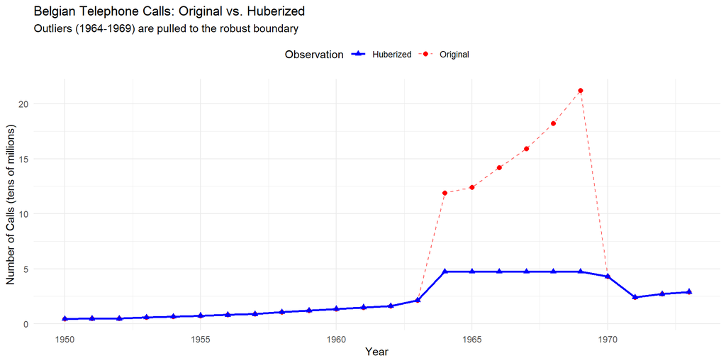